# evergreen spinups

### Looking at how different amounts of spin up years affects the subsequent years that include drought (2011-2018)

#### Look at rainfall data being used real quick

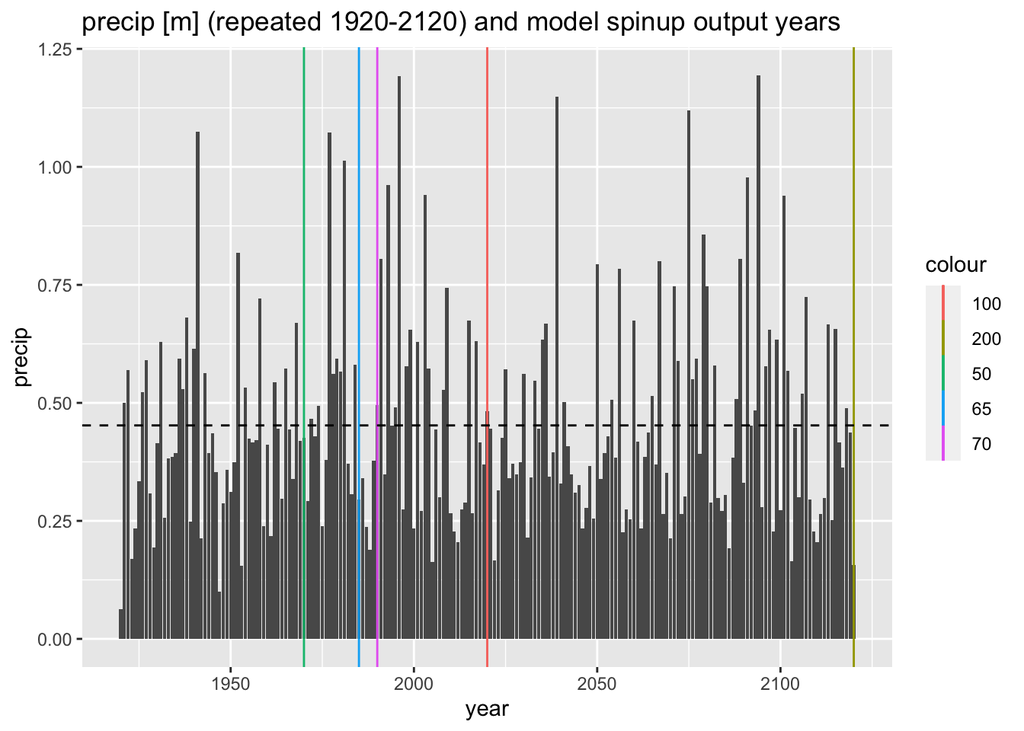

#### Look at all runs averaged by day

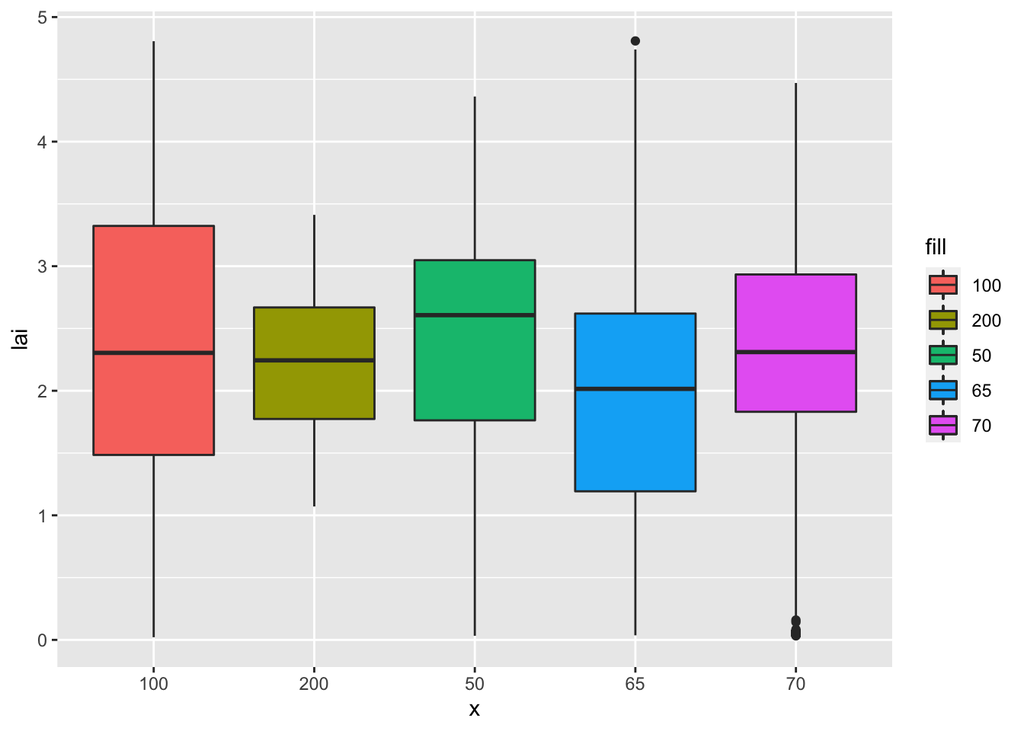

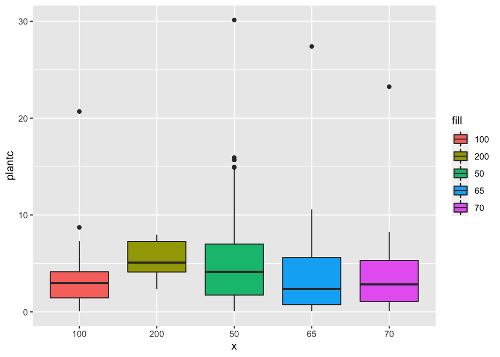

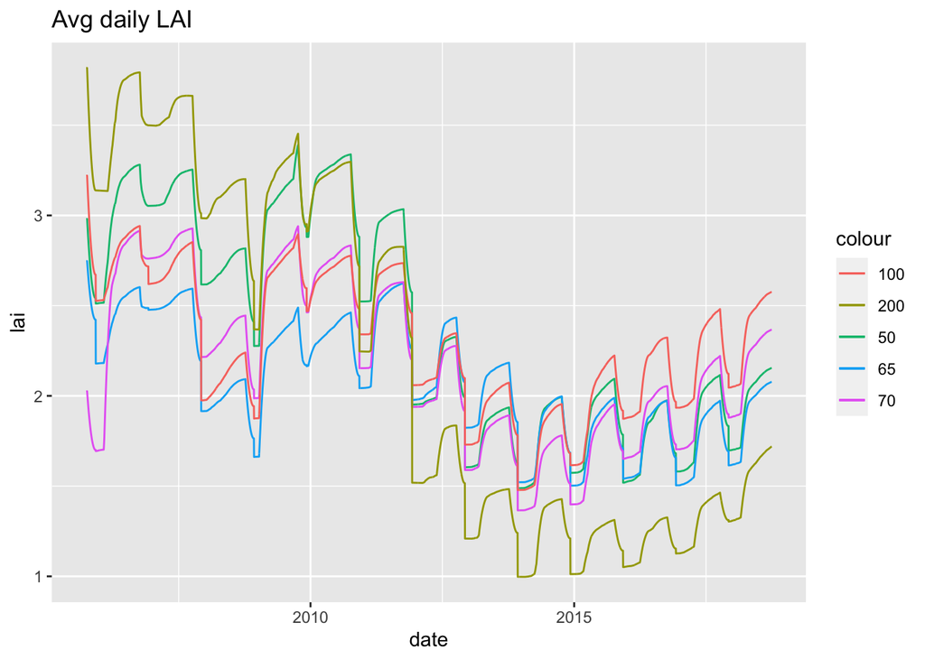

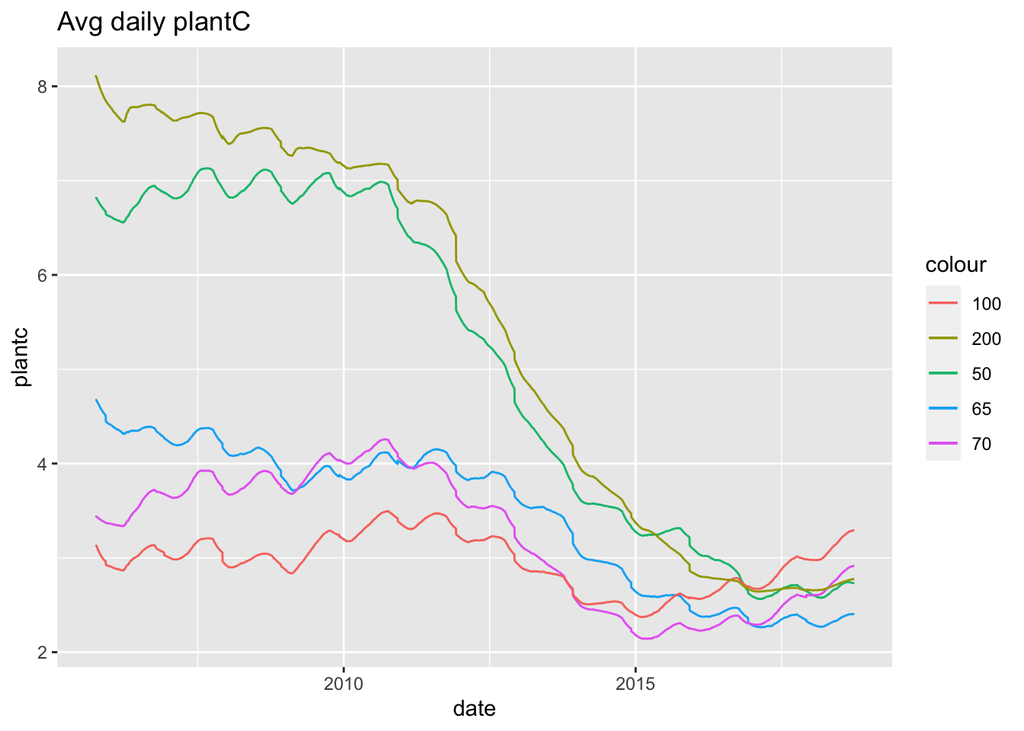

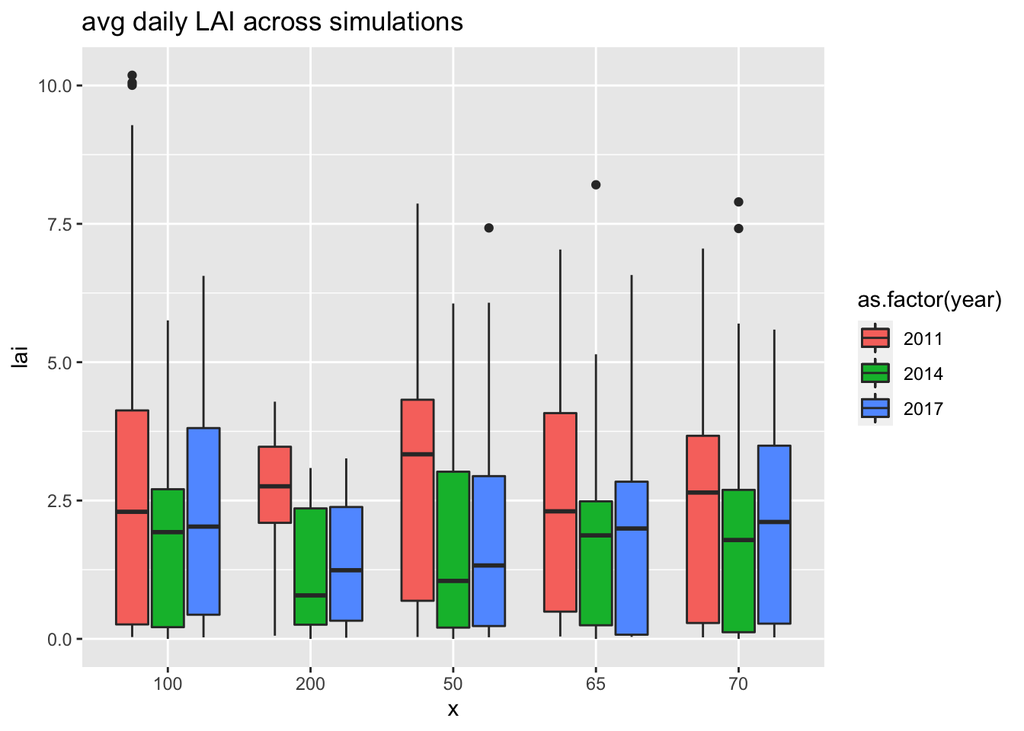

#### Use average (across runs) from june / july each year

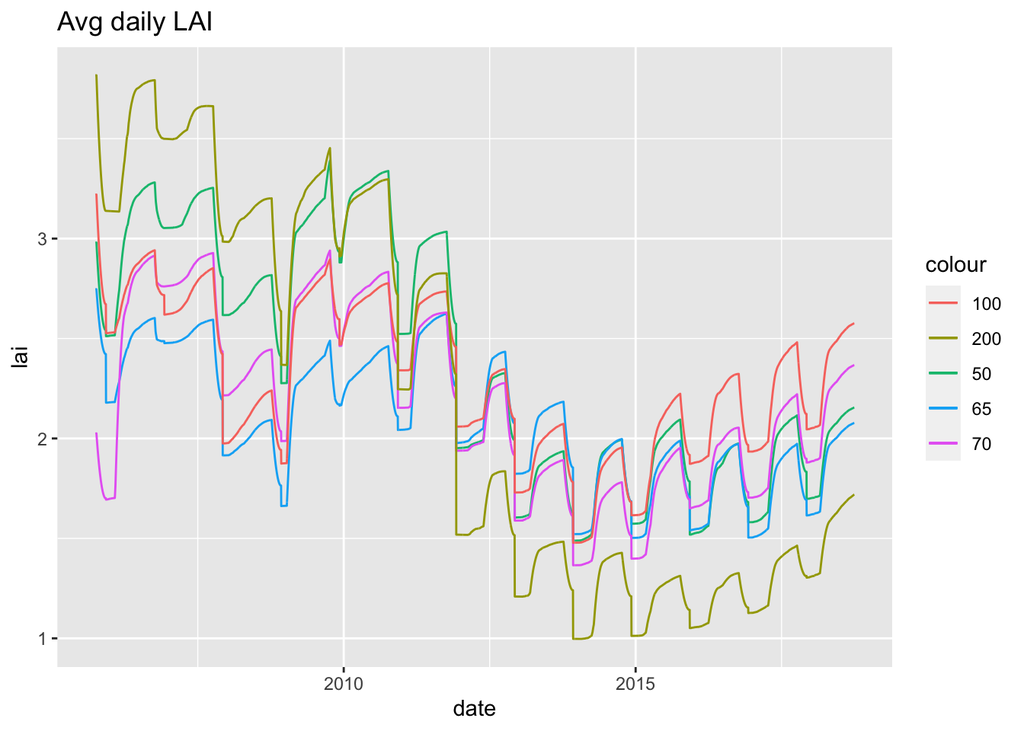

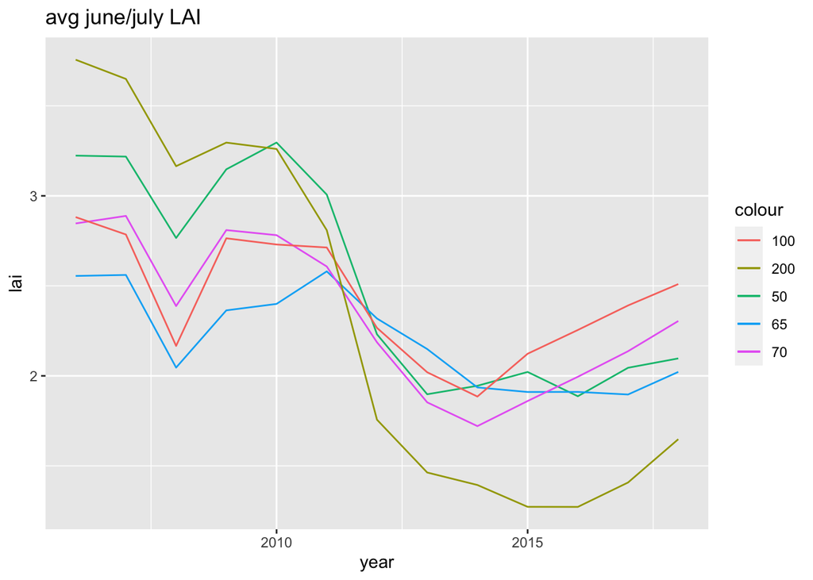

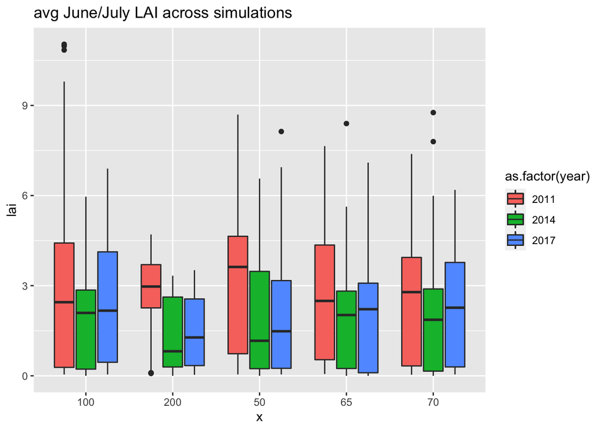

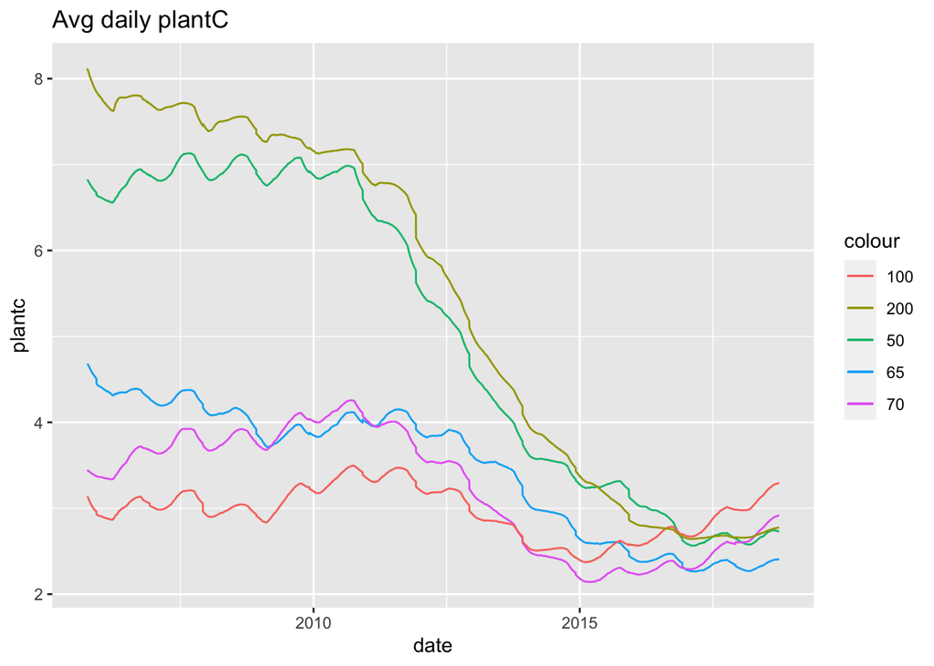

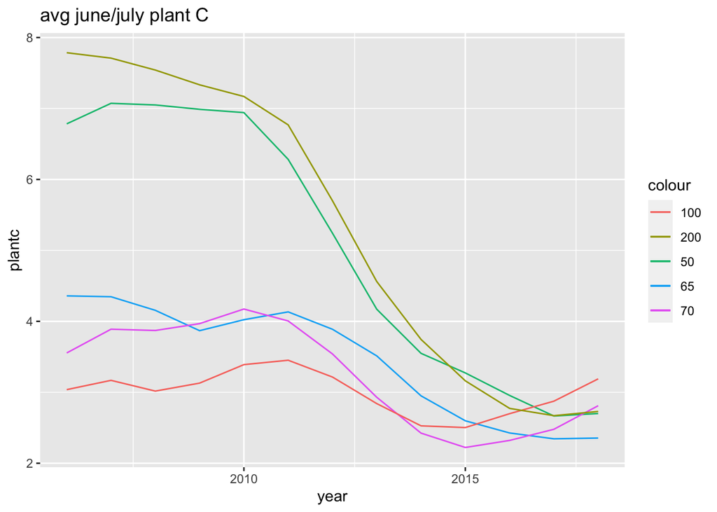

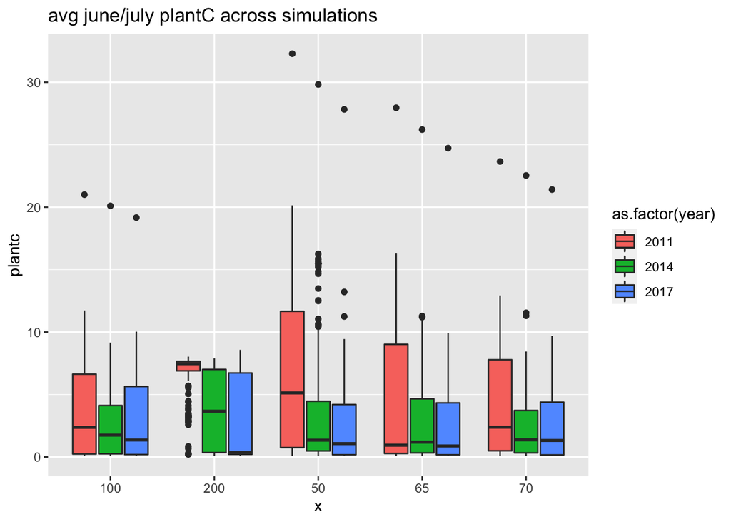

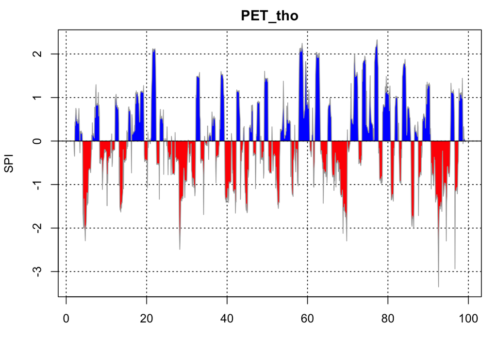

```r
clim <- read.csv("/Volumes/GoogleDrive/My Drive/clim_files/sb_all_clim_UPDATED.csv")
clim$date <- as.Date(clim$cal)

pre <- clim %>%
  #dplyr::filter(year > 1948 & year< 2018) %>%
  mutate(rain_mm = p*1000) %>%
  group_by(year(date), month(date)) %>%
  summarize_at(vars(rain_mm), funs(sum))

tave <- clim %>% mutate(tmid = (tmax+tmin)/2) %>%
  #dplyr::filter(year>1948 & year<2018) %>%
  group_by(year(date), month(date)) %>%
  summarize_at(vars(tmid), funs(mean))

pet.thorn <- SPEI::thornthwaite(Tave = tave$tmid, lat=34.42, na.rm=F)

bal0 = pre$rain_mm - pet.thorn

spei.thor <- SPEI::spei(data=bal0, scale = 12)

plot(spei.thor)
```

```r
thor <- as.data.frame(spei.thor$fitted)
tmp2 <- as_tibble(thor$PET_tho)
tmp2$year = pre$`year(date)`
tmp2$month = pre$`month(date)`
tmp2$yr.mo = paste(tmp2$year, tmp2$month, sep="-")
```

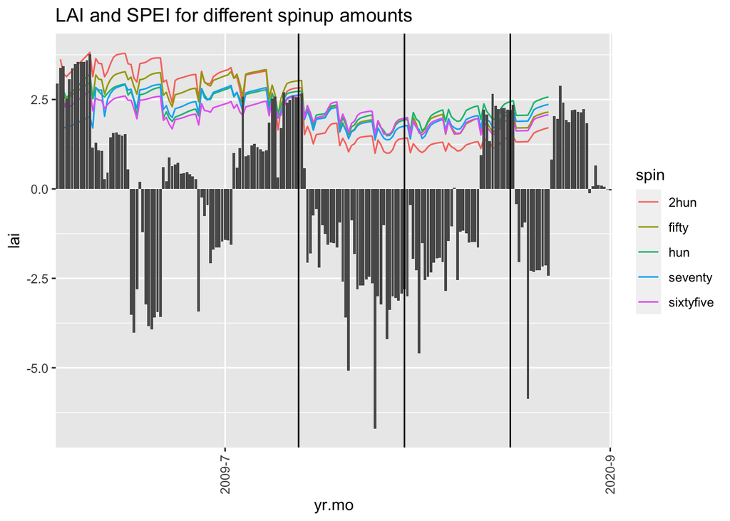

```r
fifty$spin = "fifty"
sixtyfive$spin = "sixtyfive"
seventy$spin = "seventy"
eighty$spin = "hun"
hundo$spin = "2hun"

allsims <- rbind(fifty, sixtyfive, seventy, nine=eighty, twohundo = hundo)


allsims %>%
  group_by(year, month, spin) %>%
  summarize_at(vars(lai), funs(mean)) %>%
  dplyr::filter(year<2019) %>%
  mutate(yr.mo = paste(year, month, sep="-")) %>%
  ggplot() +
  geom_line(aes(x=yr.mo, y=lai, col=spin, group=spin)) +
  geom_col(data=tmp2[tmp2$year>2004,], aes(x=yr.mo, y=value*2)) +
  theme(axis.text.x = element_text(angle = 90, hjust=1, vjust=0.5)) +
  scale_x_discrete(breaks = levels(as.factor(tmp2$yr.mo))[floor(seq(1,
                                                     nlevels(as.factor(tmp2$yr.mo)), length.out = 10))]) +
  geom_vline(aes(xintercept='2017-8')) +
  geom_vline(aes(xintercept='2014-8')) +
  geom_vline(aes(xintercept='2011-8')) +
  ggtitle("LAI and SPEI for different spinup amounts")
```

- Look at ones that meet conditions and see how it crashes - what happens to cpool
- look at worldfile that gets rewritten - what is starting point
- what do carbon pools look like at first year (end of spinup)
- check rain and the parameters for allocation
- STATIC epc.phenology_flag , need to change the epc.leafon that will control new growth - needs to do this before summer drought (use april 1 as leafon and 30 some days as n days expand; leafoff is beg Sept); static fixes annual growth to peak in the summertime